# B2.324_Pec1_Lectura y preparación de datos_MiguelNicolasRodriguez

Miguel Nicolas Rodriguez Martinez

16 de abril de 2018

## PEC1 Mineria de datos, Miguel Nicolas ROdriguez Martinez

# 1

En esta practica trabajaremos con los datos de opendata de barcelona y haremos un analisis descriptivo sobre el. Primero, cargamos los datos.

```r
accidentes = read.csv("Accidentes2017.csv", header = TRUE, encoding="UTF-8")
```

# 2

Veamos como es nuestro dataframe, con la funcion dim vemos las dimensiones de nuestro dataframe. COn la funcion str() veremos que tipo de datos tiene nuestro dataframe y el nombre de las columnas.

```r
dim(accidentes)
```

```
## [1] 12148    28
```

```r
str(accidentes)
```

```
## 'data.frame':    12148 obs. of  28 variables:
##  $ Número_d.expedient          : Factor w/ 9433 levels "2017S000001    ",..: 1 2 3 4 4 5 6 6 7 8 ...
##  $ Codi_districte              : int  5 2 2 10 10 1 2 2 3 9 ...
##  $ Nom.districte               : Factor w/ 11 levels "Ciutat Vella",..: 11 3 3 9 9 1 3 3 10 8 ...
##  $ Codi_barri                  : int  26 5 6 66 66 1 7 7 18 62 ...
##  $ Nom_barri                   : Factor w/ 74 levels "Baró de Viver",..: 62 18 41 20 20 24 32 32 66 17 ...
##  $ Codi_carrer                 : int  187105 197302 89004 243206 243206 352100 191204 191204 270209 133300 ...
##  $ Nom.carrer                  : Factor w/ 1401 levels "","A Zona Franca",..: 755 816 356 970 970 1345 769 769 1070 550 ...
##  $ Num_postal.                 : Factor w/ 2004 levels "","0         ",..: 597 836 1756 717 717 65 1310 1310 372 37 ...
##  $ Descripció_dia_setmana      : Factor w/ 7 levels "Dijous","Dilluns",..: 6 6 6 6 6 6 6 6 6 6 ...
##  $ Dia.setmana                 : Factor w/ 7 levels "Dc","Dg","Dj",..: 2 2 2 2 2 2 2 2 2 2 ...
##  $ Descripció.tipus.dia        : Factor w/ 1 level "Laboral": 1 1 1 1 1 1 1 1 1 1 ...
##  $ NK.Any                      : int  2017 2017 2017 2017 2017 2017 2017 2017 2017 2017 ...
##  $ Mes.de.any                  : int  1 1 1 1 1 1 1 1 1 1 ...
##  $ Nom.mes                     : Factor w/ 12 levels "Abril","Agost",..: 5 5 5 5 5 5 5 5 5 5 ...
##  $ Dia.de.mes                  : int  1 1 1 1 1 1 1 1 1 1 ...
##  $ Descripció.torn             : Factor w/ 3 levels "Matí","Nit","Tarda": 2 2 1 1 1 1 1 1 3 1 ...
##  $ Hora.de.dia                 : int  4 2 7 7 7 11 10 10 14 12 ...
##  $ Descripció.causa.vianant    : Factor w/ 6 levels "Altres","Creuar per fora pas de vianants",..: 5 5 5 5 5 5 5 5 5 5 ...
##  $ Desc._Tipus_vehicle_implicat: Factor w/ 31 levels "Altres vehicles amb motor",..: 31 19 19 13 13 8 19 19 13 3 ...
##  $ Descripció_sexe             : Factor w/ 3 levels "Desconegut","Dona",..: 3 3 2 2 3 3 2 3 2 2 ...
##  $ Edat                        : Factor w/ 100 levels "0","1","10","11",..: 48 44 22 37 33 60 27 31 31 93 ...
##  $ Descripció_tipus_persona    : Factor w/ 3 levels "Conductor","Passatger",..: 1 1 1 2 1 3 2 1 1 2 ...
##  $ Descripció_situació         : Factor w/ 6 levels "Altres","Citado",..: 5 5 5 4 5 4 4 5 5 4 ...
##  $ Descripció_victimització    : Factor w/ 8 levels "Ferit greu: hospitalització superior a 24h",..: 6 6 6 6 6 6 6 6 6 6 ...
##  $ Coordenada_UTM_.X.          : Factor w/ 6663 levels "","424530,80",..: 1934 5412 5071 5835 5835 3624 3445 3445 1199 5050 ...
##  $ Coordenada_UTM_.Y.          : Factor w/ 6673 levels "","4575106,49",..: 3547 3043 3919 3112 3112 1441 2828 2828 1032 5557 ...
##  $ Long                        : Factor w/ 6444 levels "'","2.095684",..: 1900 5245 4900 5645 5645 3530 3351 3351 1190 4847 ...
##  $ Lat                         : Factor w/ 6386 levels "'","41.322371",..: 3368 2947 3747 2999 2999 1408 2711 2711 991 5291 ...
```

# 3

A continuacion cambiaremos los nombres de las columnas de nuestro dataframe.

```r
colnames(accidentes) <- c('Exp','DistC','DistN','BarC','BarN','CalleC','CalleN','PC','DiaSN','DiaSn','DiaTipo','Año','Mesn','MesN','Dia','Turno','Hora','Causa','Veh','Sexo','Edad','PersT','Sit','Vict','X','Y','Long','Lat')

str(accidentes)
```

```
## 'data.frame':    12148 obs. of  28 variables:
##  $ Exp    : Factor w/ 9433 levels "2017S000001    ",..: 1 2 3 4 4 5 6 6 7 8 ...
##  $ DistC  : int  5 2 2 10 10 1 2 2 3 9 ...
##  $ DistN  : Factor w/ 11 levels "Ciutat Vella",..: 11 3 3 9 9 1 3 3 10 8 ...
##  $ BarC   : int  26 5 6 66 66 1 7 7 18 62 ...
##  $ BarN   : Factor w/ 74 levels "Baró de Viver",..: 62 18 41 20 20 24 32 32 66 17 ...
##  $ CalleC : int  187105 197302 89004 243206 243206 352100 191204 191204 270209 133300 ...
##  $ CalleN : Factor w/ 1401 levels "","A Zona Franca",..: 755 816 356 970 970 1345 769 769 1070 550 ...
##  $ PC     : Factor w/ 2004 levels "","0         ",..: 597 836 1756 717 717 65 1310 1310 372 37 ...
##  $ DiaSN  : Factor w/ 7 levels "Dijous","Dilluns",..: 6 6 6 6 6 6 6 6 6 6 ...
##  $ DiaSn  : Factor w/ 7 levels "Dc","Dg","Dj",..: 2 2 2 2 2 2 2 2 2 2 ...
##  $ DiaTipo: Factor w/ 1 level "Laboral": 1 1 1 1 1 1 1 1 1 1 ...
##  $ Año    : int  2017 2017 2017 2017 2017 2017 2017 2017 2017 2017 ...
##  $ Mesn   : int  1 1 1 1 1 1 1 1 1 1 ...
##  $ MesN   : Factor w/ 12 levels "Abril","Agost",..: 5 5 5 5 5 5 5 5 5 5 ...
##  $ Dia    : int  1 1 1 1 1 1 1 1 1 1 ...
##  $ Turno  : Factor w/ 3 levels "Matí","Nit","Tarda": 2 2 1 1 1 1 1 1 3 1 ...
##  $ Hora   : int  4 2 7 7 7 11 10 10 14 12 ...
##  $ Causa  : Factor w/ 6 levels "Altres","Creuar per fora pas de vianants",..: 5 5 5 5 5 5 5 5 5 5 ...
##  $ Veh    : Factor w/ 31 levels "Altres vehicles amb motor",..: 31 19 19 13 13 8 19 19 13 3 ...
##  $ Sexo   : Factor w/ 3 levels "Desconegut","Dona",..: 3 3 2 2 3 3 2 3 2 2 ...
##  $ Edad   : Factor w/ 100 levels "0","1","10","11",..: 48 44 22 37 33 60 27 31 31 93 ...
##  $ PersT  : Factor w/ 3 levels "Conductor","Passatger",..: 1 1 1 2 1 3 2 1 1 2 ...
##  $ Sit    : Factor w/ 6 levels "Altres","Citado",..: 5 5 5 4 5 4 4 5 5 4 ...
##  $ Vict   : Factor w/ 8 levels "Ferit greu: hospitalització superior a 24h",..: 6 6 6 6 6 6 6 6 6 6 ...
##  $ X      : Factor w/ 6663 levels "","424530,80",..: 1934 5412 5071 5835 5835 3624 3445 3445 1199 5050 ...
##  $ Y      : Factor w/ 6673 levels "","4575106,49",..: 3547 3043 3919 3112 3112 1441 2828 2828 1032 5557 ...
##  $ Long   : Factor w/ 6444 levels "'","2.095684",..: 1900 5245 4900 5645 5645 3530 3351 3351 1190 4847 ...
##  $ Lat    : Factor w/ 6386 levels "'","41.322371",..: 3368 2947 3747 2999 2999 1408 2711 2711 991 5291 ...
```

# 4

Esto es el dataset con el que contaremos y lo que nos proporcionan.

# 5

Ahora para entender con que dimnensiones unicas contamos, vamos a ver cuantos accidentes unicos tenemos, para eso usaremos el expediente como codigo y contaremos los unicos que hay. Con la funcion sapply, contaremos el tamaño de la lista unica que nos queda al sacar solo los distintos en length. Seleccionaremos solo la columna expediente ya que es la que nos identifica un accidente, tambien lo tendremos que pasar a un dataframe. El numero de personas haremos lo mismo pero sin la funcion unique ya que asumimos que cada linea de nuestro dataset es una persona.

```r
numero_de_accidentes <- sapply(as.data.frame(accidentes$Exp), function(x) length(unique(x)))
numero_de_personas <- sapply(as.data.frame(accidentes$Exp), function(x) length(x))

numero_de_accidentes
```

```
## accidentes$Exp
##           9433
```

```r
numero_de_personas
```

```
## accidentes$Exp
##          12148
```

# 6

Para mostrar la distribucion de el % de hombres y mujeres dentro de nuestro dataset usaremos un piechart. Primero extraeremos los diferentes sexos y su numero de valores, es decir los que se cuentan, usaremos la funcion aggregate que nos devolvera 2 resultados, los valores diferentes que hay y el numero de veces que se han visto. Despues sacaremos la distribucion de porcentaje en la que usaremos la funcion round para que nos redondee el resultado y quede mejor para la vista despues. Despues sacamos los label que usaremos y le añadimos el porcentaje, para por ultimo, mostrarlo.

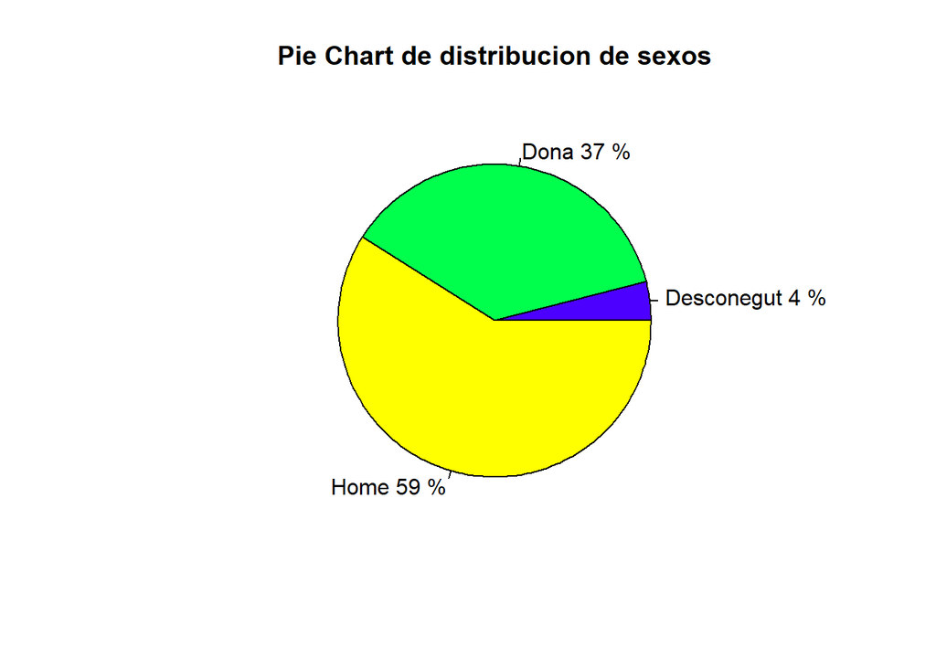

```r
distribucion_del_sexo <- aggregate(data.frame(count = accidentes$Sexo), list(value = accidentes$Sexo), length)
porcentaje_de_sexos <- round(distribucion_del_sexo$count/sum(distribucion_del_sexo$count)*100)

labels <- distribucion_del_sexo$value
labels <- paste(labels,porcentaje_de_sexos, "%")

pie(porcentaje_de_sexos,labels = labels, col=topo.colors(length(distribucion_del_sexo$value)),
    main="Pie Chart de distribucion de sexos")
```

# 7

Para este caso usaremos la libraria ggplot para asi ver mas tipos de graficos. Como vemos la distribucion es mas o menos igual, aunq vemos que el rango interquartil es algo mas pequeño que el de las mujeres y los desconocidos

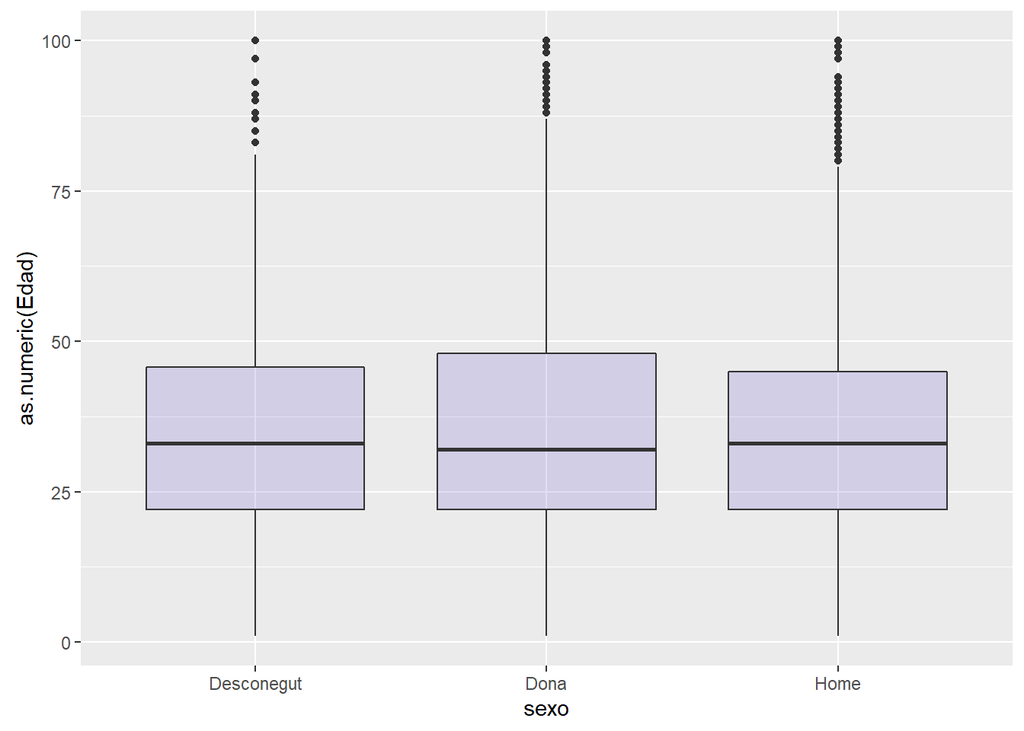

```r
ggplot(accidentes, aes(x=as.factor(Sexo), y=as.numeric(Edad))) +
    geom_boxplot(fill="slateblue", alpha=0.2) +
    xlab("sexo")
```

# 8

## 8.1

El dia de la semana ya lo tenemos como una variable categorica como hemos podido ver usando la str(), pero en caso de que no estuviera asi lo convertiriamos de una manera.

```r
accidentes$DiaSn <- as.factor(accidentes$DiaSn)
str(accidentes$DiaSn)
```

```
##  Factor w/ 7 levels "Dc","Dg","Dj",..: 2 2 2 2 2 2 2 2 2 2 ...
```

## 8.2

Listemos los datos de esta variable para ver que es lo que tenemos, no necesitamos mostrar todo, por lo tanto usaremos la funcion head() para que nosmuestre solo una muestra.

```r
head(accidentes$DiaSn)
```

```
## [1] Dg Dg Dg Dg Dg Dg
## Levels: Dc Dg Dj Dl Dm Ds Dv
```

## 8.3

Para entender mejor los dias de la semana y que sea independiente de cualquier idioma cambiaremos los niveles a el siguiente vector. Es importante que el orden del vector sea igual al orden de los niveles, como podemos ver en el apartado anterior, los niveles que tenemos son estos en ese orden: Levels: Dc Dg Dj Dl Dm Ds Dv

```r
levels(accidentes$DiaSn) <- c("D3","D7","D4","D1","D2","D6","D5")
```

## 8.4

Ahora mostraremos el numero de accidentes por dia ordenado de mayor a menor. Le pasamos la funcion order al dataframe para que nos ordene los balores por dia en descendiente.

```r
numero_de_accidentes_por_dia <- aggregate(data=accidentes, Exp ~ DiaSn, function(x) sort(length(unique(x))) )
numero_de_accidentes_por_dia <- numero_de_accidentes_por_dia[order(numero_de_accidentes_por_dia$Exp, decreasing = TRUE),]
```

## 8.5

Ahora mostraremos la distribucion de los valores con un braplot

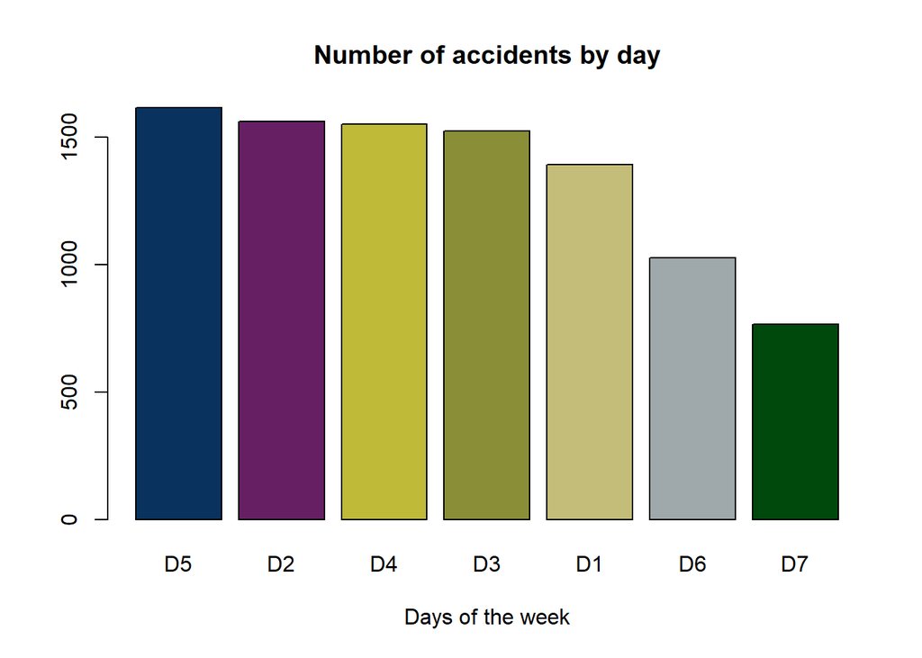

```r
barplot(numero_de_accidentes_por_dia$Exp, main="Number of accidents by day",
        col=c('#09325E','#661F63','#BFBA38','#8A8E37','#C4BD79','#9FA8AB','#00490C'),
        names.arg =numero_de_accidentes_por_dia$DiaSn,
        xlab="Days of the week")
```

# 9

# 9.1

Para el siguiente ejericio tenemos que coger todos los que esten muertos y los que esten graves, para eso usaremos la funcion grep y seleccionaremos aquellos en los que en la columna Vict se encuentre la palabra greu o mort. Dentro de la funcin grep le pasamos los argumentos de mort y greu separados por | eso significa que uno u otro, tambien ponemos las palabras a comparar en minusculas.

```r
accidentes_graves <- accidentes[grep("mort|greu", tolower(accidentes$Vict)), ]
head(accidentes_graves$Vict)
```

```
## [1] Ferit greu Ferit greu Mort       Ferit greu Ferit greu Ferit greu
## 8 Levels: Ferit greu: hospitalització superior a 24h ... Mort (dins 24h posteriors accident)
```

## 9.2

Para mostrar en una grafica de las distintas causas de accidentes, lo primero que haremos sera seleccionar solo una fila de cada uno de los accidentes, despues como en el anterior agruparemos por causa el numero de expedientes (accidentes), sacamos el porcentaje construimos el piechart y lo mostramos.

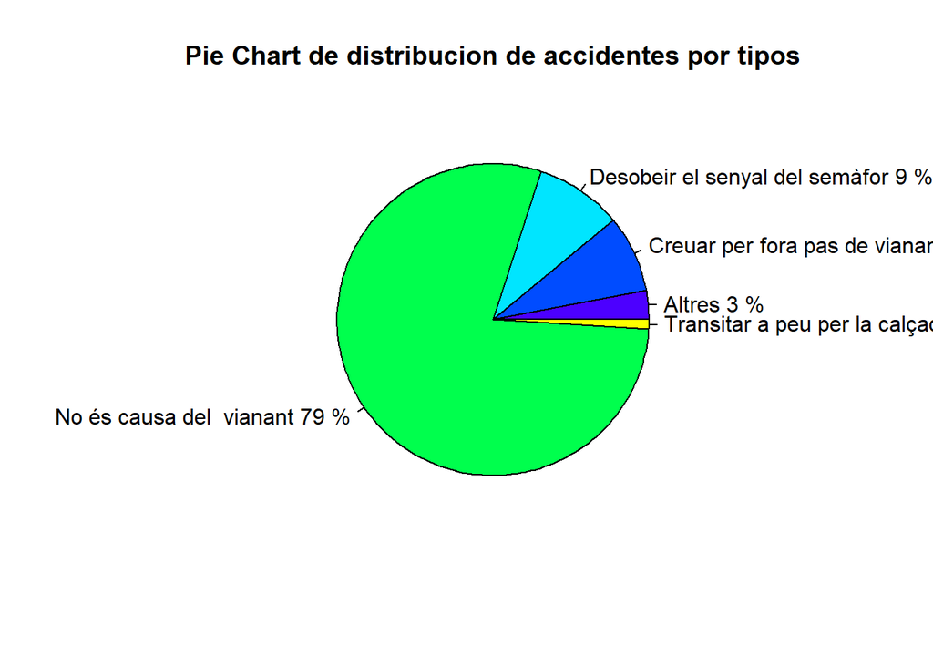

```r
accidentes_unicos_tipo <- aggregate(data.frame(Causa = accidentes_graves$Causa), list(Exp = accidentes_graves$Exp), unique)
distribucion_tipo_accidente <- aggregate(data.frame(Num_accidentes = accidentes_unicos_tipo$Exp), list(Causa = accidentes_unicos_tipo$Causa), length)
porcentaje_de_tipos <- round(distribucion_tipo_accidente$Num_accidentes/sum(distribucion_tipo_accidente$Num_accidentes)*100)

labels <- distribucion_tipo_accidente$Causa
labels <- paste(labels,porcentaje_de_tipos, "%")

pie(porcentaje_de_tipos,labels = labels, col=topo.colors(length(distribucion_tipo_accidente$Num_accidentes)),
    main="Pie Chart de distribucion de accidentes por tipos")
```

## 9.3

Ahora sacaremos una lista en la que nos dira el tipo de vehiculos en el que mostraremos el tipo de vehiculos implicados cuando el peaton no es el causante. Para ello primero de la lista sacaremos con los registros en los que no tenemos como causante al peaton. Despues agregaremos y sacaremos la lista y sacaremos el numero de accidentes ordenados de mayor a menor por vehiculo.

```r
accidentes_peatones_no_culpables <- accidentes_graves[grep("causa del  vianant", tolower(accidentes_graves$Causa)), ]
accidentes_graves_por_vehiculo <- aggregate(data.frame(Numero = accidentes_peatones_no_culpables$Veh), list(Vehiculo = accidentes_peatones_no_culpables$Veh), length)
accidentes_graves_por_vehiculo <- accidentes_graves_por_vehiculo[order(accidentes_graves_por_vehiculo$Numero, decreasing = TRUE),]
head(accidentes_graves_por_vehiculo)
```

```
##       Vehiculo Numero
## 9  Motocicleta    127
## 7   Ciclomotor     20
## 5    Bicicleta     17
## 11     Turisme     16
## 8    Furgoneta      6
## 10        Taxi      5
```

## 9.4

Unificamos motocicleta y ciclomotor ya que lo tomaremos como el mismo tipo de vehiculo, para ello sobreescribiremos los niveles del factor. levels()

```r
levels(accidentes_peatones_no_culpables$Veh) <- c("Altres vehicles amb motor", "Altres vehicles sense motor","Autobus","Autobus articulado","Autobus articulat","Autocar","Autocaravana","Bicicleta","Camion rgid <= 3,5 tones","Camion ragid > 3,5 tones","Camionn <= 3,5 Tm","Camion > 3,5 Tm","Motocicleta","Cuadriciclo <75cc","Desconegut","Furgoneta","Maquinaria d'obres i serveis", "Microbus <= 17","Motocicleta","Otros vehic. a motor","Quadricicle < 75 cc","Quadricicle > 75 cc","Taxi","Todo terreno","Tot terreny","Tractocamion","Tractor camion","Tranvia o tren","Tren o tramvia","Turisme","Turismo" )
```

## 9.5

Mostramos los 3 vehiculos mas frecuentes, para ello usamos head y le pasamos 3.

```r
accidentes_graves_por_vehiculo <- aggregate(data.frame(Numero = accidentes_peatones_no_culpables$Veh), list(Vehiculo = accidentes_peatones_no_culpables$Veh), length)
accidentes_graves_por_vehiculo <- accidentes_graves_por_vehiculo[order(accidentes_graves_por_vehiculo$Numero, decreasing = TRUE),]
head(accidentes_graves_por_vehiculo, 3)
```

```
##       Vehiculo Numero
## 7  Motocicleta    147
## 5    Bicicleta     17
## 10     Turisme     16
```

## 9.6

Ahora buscaremos el tipo de persona mas afectada por los accidentes en los que esta implicada una motocicleta. Para ello, primero seleccionaremos los vehiculos en los que las motocicletas han sido las causantes, despues agruparemos y mostraremos. Sobre todo devemos saber que niveles hay en la columna PersT para ver cual es la victima.

```r
personas_afectadas_por_motocicleta <- accidentes_peatones_no_culpables[accidentes_peatones_no_culpables$Veh == "Motocicleta", ]
personas_afectadas_agrupadas <- aggregate(data.frame(Numero = personas_afectadas_por_motocicleta$Veh), list(Victima = personas_afectadas_por_motocicleta$PersT), length)
head(personas_afectadas_agrupadas)
```

```
##     Victima Numero
## 1 Conductor    124
## 2 Passatger     19
## 3   Vianant      4
```

# 10

Ahora guardaremos en un csv las siguientes columnas, número de expediente, la causa, el vehículo y tipo de persona implicada.

```r
dataframe_guardar <- accidentes_graves[c("Exp","Causa","Veh","PersT")]
write.csv(dataframe_guardar, file = "accidentesgraves.csv")
```

# 11 Conclusiones.

Como podemos ver, hay mas hombres afectados por los accidentes, esto puede venir causado de que mas hombres conducen vehiculos. Segun la DGT hay mas hombres conduciendo que mujeres [fuente](http://www.dgt.es/es/seguridad-vial/estadisticas-e-indicadores/censo-conductores/tablas-estadisticas/). No existe gran diferencia en la distribucion entre hombres y mujeres en la edad, se ve como la distribucion de los hombres es mas compacta ya que el rango interquartil es mas corto.

Los viernes es cuando se producen mas accidentes, esto puede ser por un tema psicologico en el que se apunta a la ansiedad como uno de los principales causantes en varios estudios [fuente](http://www.elcorreo.com/sociedad/viernes-dias-accidentes-20170929110250-nt.html). Los sabados y los domingos es cuando hay menos accidentes pudiendo ser por una disminucion de trafico o por que fluye menos trafico pesado [fuente](https://www.muyinteresante.es/curiosidades/preguntas-respuestas/hay-mas-o-menos-accidentes-de-trafico-los-fines-de-semana-201378124639).

La causa mas comun identificada del accidente es por saltarse el semaforo, con un alto % en el que solo se sabe que no es culpable el viandante.